# FIT3152 Assignment 1

Ashley Yow Shu Ping 32227523

```r
knitr::opts_chunk$set(echo = TRUE, message = FALSE, warning = FALSE)
```

**Defining libraries**

```r
library(ggplot2)
library(tidyr)
library(dplyr)
library(reshape2) #the use of melt()
library(cluster) #for k-means clustering
library(factoextra) #for cluster plot
```

##### **Question 1**

**Reading the data from the CSV file**

```r
rm(list = ls())
set.seed(32227523)
cvbase = read.csv("PsyCoronaBaselineExtract.csv")
cvbase <- cvbase[sample(nrow(cvbase), 40000), ]
```

**Descriptive analysis on the data**

Dimension of the data: There are 40000 rows and 54 columns in this data set. A summary of the data set is also generated to have a general overview of each attribute.

```r
dim(cvbase)
summary (cvbase)
```

As for the analysis of data types, the data set is of type list, and there are two different data types within the list itself, where all attributes except coded_country (is of type character) belong to the integer data type. From here we can clearly conclude that out of 54 attributes that exists in the data set, only 1 attribute (coded_country) is a non-numerical attribute, whilst the remaining 53 attributes appear to be numerical attributes.

```r
typeof(cvbase)
str(cvbase)
```

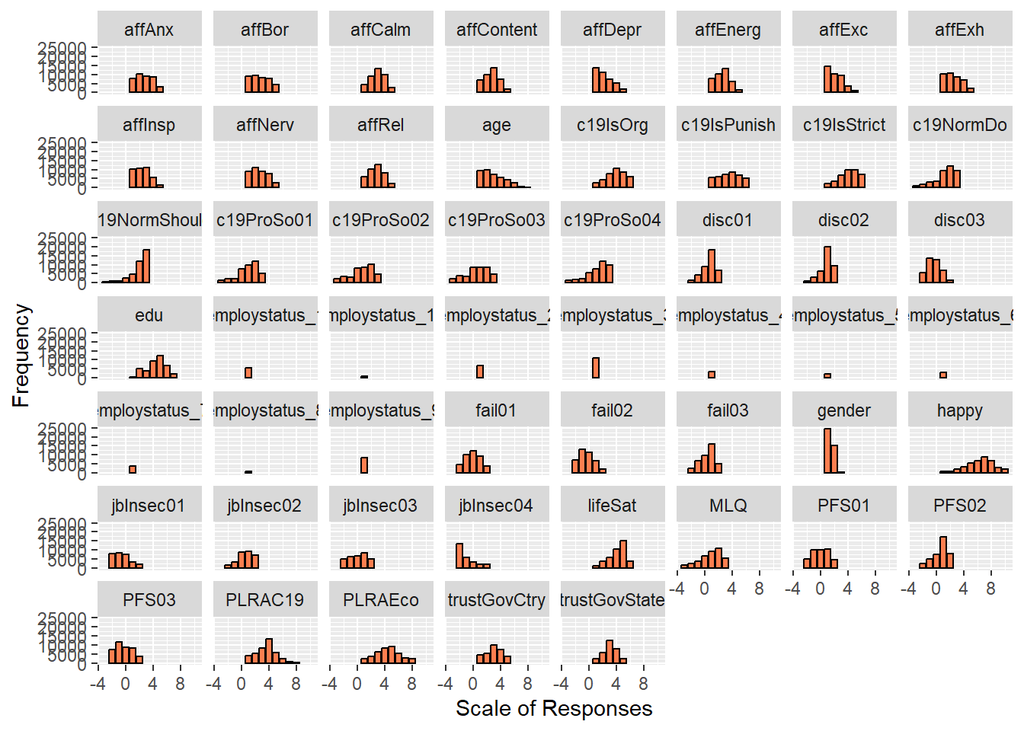

```r
#making a temp data frame that only has all numerical attributes
df = select(cvbase, -c(coded_country))
#plotting the attributes
df %>%
  pivot_longer(affAnx:c19ProSo04, names_to = "attribute", values_to = "response") %>%
  ggplot(aes(x = response)) +
  geom_bar(fill="coral", color="black") +
  facet_wrap(vars(attribute), ncol = 8) +
  labs(x = "Scale of Responses", y = "Frequency")
```

There is a total of 426718 missing values (NA) in this data set. Among the total number of missing values, the attribute employstatus_8 has the most value of NA which is 39265 records.

```r
sum(is.na(cvbase))
```

```
## [1] 426718
```

```r
#searching for the attribute with the most missing values
max_missingval = 0
max_index = 0
for(i in 1:ncol(cvbase)) {
  if (max_missingval < sum(is.na(cvbase[,i]))){
    max_missingval = sum(is.na(cvbase[,i]))
    max_index = i
  }
}
print(colnames(cvbase[max_index]))
```

```
## [1] "employstatus_8"
```

```r
print(max_missingval)
```

```
## [1] 39265
```

There are a total of 110 locations/countries (including unspecified locations) that participated in this survey from the sampled data set.

```r
unique(cvbase$coded_country)
```

```
##   [1] "United States of America" "Philippines"
##   [3] "Italy"                    "Kazakhstan"
##   [5] "Ukraine"                  "Kosovo"
##   [7] "Romania"                  "Argentina"
##   [9] "Brazil"                   "Hungary"
##  [11] "Turkey"                   "South Africa"
##  [13] "Taiwan"                   "Germany"
##  [15] "Republic of Serbia"       "Greece"
##  [17] "Spain"                    "Canada"
##  [19] "United Kingdom"           "China"
##  [21] "Netherlands"              "Saudi Arabia"
##  [23] "France"                   "Indonesia"
##  [25] "Trinidad and Tobago"      "South Korea"
##  [27] "Poland"                   "Japan"
##  [29] "Malaysia"                 "Iran"
```

[output cut: 40 more lines]

```r
length(unique(cvbase$coded_country))
```

```
## [1] 110
```

**Pre-processing the data file**

Rows with most NA are removed to simplify further analysis, the number 27 was chosen as there are a total of 54 attributes, and at least half of the attributes are to have data in a record for it to give sufficient data. Records without a specified country is also removed. Since the employstatus attribute each have NA values close to the number of records (viewed from summary of cvbase), the columns will be dropped to prevent potential problems in modelling and prediction.

```r
clean_cvbase = cvbase[rowSums(is.na(cvbase)) < 27, ]
clean_cvbase = clean_cvbase[(clean_cvbase$coded_country != ""),]
clean_cvbase = select(clean_cvbase, -c(employstatus_1, employstatus_2, employstatus_3,
                                       employstatus_4, employstatus_5,employstatus_6,
                                       employstatus_7, employstatus_8, employstatus_9,
                                       employstatus_10))
```

Renumbering the row indexes

```r
rownames(clean_cvbase) <- 1:nrow(clean_cvbase)
```

##### **Question 2**

###### **2(a)**

**Focus country: Italy**

**Grouping the data by focus country and other countries**

```r
focuscountry_data <- clean_cvbase[(clean_cvbase$coded_country == "Italy"),]
rownames(focuscountry_data) <- 1:nrow(focuscountry_data)
othercountries_data <- clean_cvbase[(clean_cvbase$coded_country != "Italy"),]
rownames(othercountries_data) <- 1:nrow(othercountries_data)
```

**Plotting out the distribution in attributes for both groups to observe differences**

Based on the chart depicting the responses of the two groups, in terms of how affected people were, citizens of Italy expressed great discontent in comparison to the rest of the world, with their response to that affect mostly being very slightly or not at all Content, whereas the majority of citizens from other countries felt moderately content. In Italy, more people appear to be very slightly or not at all calm than quite a bit calm, whereas people in other countries are the contrary. In Italy, there are more people who feel uninspired at all than moderately inspired, whereas people in other countries are more moderately inspired than totally uninspired.There appears to be some respondents aged between 65 to 75 in Italy, more in amount in relative comparison to other countries, but no one from the age group 85 and above responded the survey whereas in other countries, there appears to be a small group of elderly of that age. As for pro social behaviours, more citizens of Italy stand neutral when it comes to their willingness to help others who suffer from the virus than to be somewhat agreeing to this idea. In other countries, more people somewhat agree on helping others who are suffering from the pandemic than not having an opinion about it at all. The same pattern of observation can be made with c19ProSo02, with more people in Italy neither agree or disagree to be willing to make donations to those who suffer from Coronavirus than to somewhat agree to it, and vice versa for the people outside of Italy. As for the willingness to make personal sacrifices to prevent the spread of the Coronavirus, the majority of Italians are strongly willing to do so, in comparison to the majority in the other countries. The respondents of the survey in Italy have reached higher education as their highest level of education, whereas the majority of others in the world have received a bachelors degree. In Italy, most people do not have an opinion on whether or not their group is worst off in this pandemic compared to other people in the same country, whilst the majority in other countries have mostly disagreed with this statement. Looking into job insecurities, most people in other countries feel pretty certain of their job security, and the majority in Italy stand neutral in believing whether or not they might lose their job. In terms of the aspect of perceived financial strain, the majority of people in Italy do not think they are particularly strained nor not strained financially. Hence, they also stand neutral on whether or not they find it difficult to pay for expenses. However, most people in other countries agree that they are financially strained, but expressed otherwise when it comes to the ability to pay for expenses.

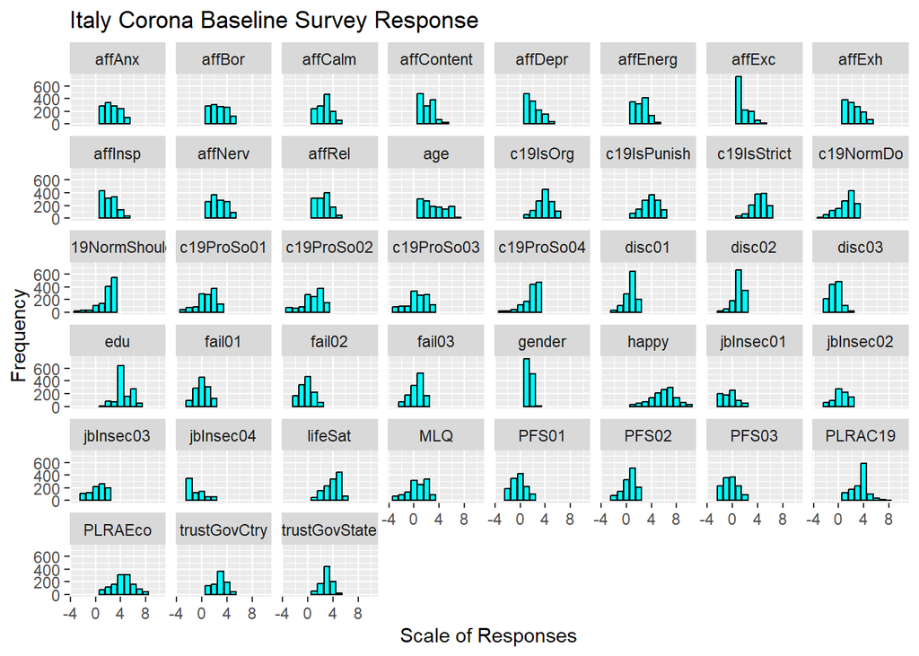

```r
#drop the column coded_country as it serves no purpose for graph plotting and comparisons
focuscountry_data = select(focuscountry_data, -c(coded_country))
othercountries_data = select(othercountries_data, -c(coded_country))

#plot small multiples of bar charts for focus country data
focuscountry_data %>%
  pivot_longer(affAnx:c19ProSo04, names_to = "attribute", values_to = "response") %>%
  ggplot(aes(x = response)) +
  geom_bar(fill="cyan", color="black") +
  facet_wrap(vars(attribute), ncol = 8) +
  labs(x = "Scale of Responses", y = "Frequency") +
  ggtitle("Italy Corona Baseline Survey Response")
```

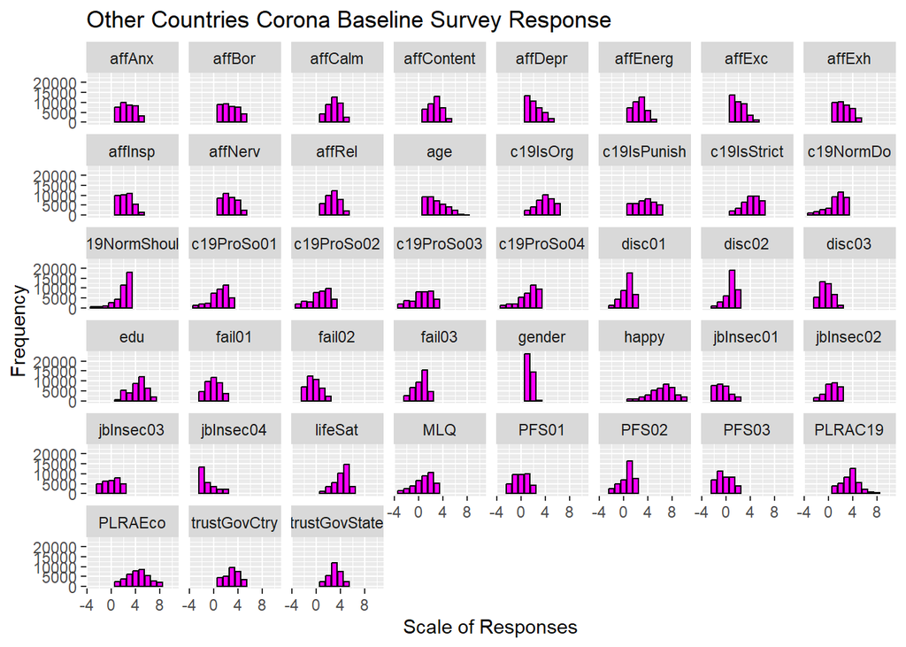

```r
#plot small multiples of bar charts for other countries data
othercountries_data %>%
  pivot_longer(affAnx:c19ProSo04, names_to = "attribute", values_to = "response") %>%
  ggplot(aes(x = response)) +
  geom_bar(fill="magenta", color="black") +
  facet_wrap(vars(attribute), ncol = 8) +
  labs(x = "Scale of Responses", y = "Frequency") +
  ggtitle("Other Countries Corona Baseline Survey Response")
```

###### **2(b)**

**Analysing how well participants responses in Italy predict c19ProSo01**

c19ProSo01 collects the information on how willing people are to help others who suffer from Coronavirus. According to the summary of the fitted model using linear regression, jbInsec02 and c19NormShould appears to be the best predictors for this pro social behaviour due to having the lowest p-values among the rest of the potential predictors. c19NormDo, c19IsOrg, gender and edu seem like potential predictors too (because a p-value lower than 0.05), but we would barely have enough evidence to prove of them being strong predictors. A correlation heat map is plotted to spot for attributes with potential relationships with each other. The predictors above are shown to have greater relationship compared to the rest as well.

```r
#create data sets with only the predictors and one pro-social attribute each for linear modelling
focuscountry_pro1 = select(focuscountry_data, -c(c19ProSo02, c19ProSo03, c19ProSo04))
#create a linear regression model for all pro-social attr
italy1.fit <-lm(c19ProSo01 ~ ., data = focuscountry_pro1, na.action = na.exclude)
#check for significant predictors for all pro-social attitude attributes
summary(italy1.fit)
```

```
##
## Call:
## lm(formula = c19ProSo01 ~ ., data = focuscountry_pro1, na.action = na.exclude)
##
## Residuals:
##     Min      1Q  Median      3Q     Max
## -4.0854 -0.7099  0.0508  0.8951  2.8145
##
## Coefficients:
##                Estimate Std. Error t value Pr(>|t|)
## (Intercept)   -1.846340   0.717686  -2.573  0.01042 *
## affAnx        -0.105845   0.068564  -1.544  0.12336
## affBor         0.028703   0.053852   0.533  0.59430
## affCalm       -0.010634   0.076647  -0.139  0.88971
## affContent     0.119091   0.084023   1.417  0.15707
## affDepr       -0.027640   0.075237  -0.367  0.71352
## affEnerg       0.075388   0.077982   0.967  0.33420
## affExc        -0.062490   0.076217  -0.820  0.41271
## affNerv       -0.047060   0.074338  -0.633  0.52703
## affExh         0.100357   0.062988   1.593  0.11181
## affInsp        0.051235   0.072420   0.707  0.47965
## affRel        -0.055500   0.078599  -0.706  0.48048
## PLRAC19        0.007686   0.051240   0.150  0.88084
## PLRAEco       -0.012376   0.047402  -0.261  0.79415
## disc01         0.052378   0.097652   0.536  0.59197
## disc02         0.150676   0.096564   1.560  0.11938
## disc03         0.129631   0.078688   1.647  0.10018
## jbInsec01      0.052166   0.079968   0.652  0.51452
## jbInsec02      0.203745   0.077901   2.615  0.00921 **
## jbInsec03      0.091468   0.064192   1.425  0.15488
## jbInsec04      0.024941   0.071152   0.351  0.72610
## PFS01         -0.061573   0.114624  -0.537  0.59141
## PFS02         -0.005701   0.077710  -0.073  0.94155
## PFS03          0.089897   0.109541   0.821  0.41227
## fail01         0.038878   0.072687   0.535  0.59301
## fail02        -0.138610   0.073653  -1.882  0.06050 .
## fail03         0.095690   0.072828   1.314  0.18955
## happy         -0.034168   0.045624  -0.749  0.45431
## lifeSat        0.058881   0.082688   0.712  0.47679
## MLQ            0.031773   0.056206   0.565  0.57216
## c19NormShould  0.141700   0.051213   2.767  0.00589 **
## c19NormDo      0.116716   0.050448   2.314  0.02114 *
## c19IsStrict    0.042558   0.080091   0.531  0.59543
## c19IsPunish    0.015137   0.063648   0.238  0.81213
## c19IsOrg       0.136790   0.067239   2.034  0.04250 *
## trustGovCtry  -0.100071   0.073789  -1.356  0.17573
## trustGovState  0.105669   0.084728   1.247  0.21300
## gender         0.269543   0.129109   2.088  0.03739 *
## age            0.050488   0.043880   1.151  0.25051
## edu            0.109230   0.052889   2.065  0.03948 *
## ---
## Signif. codes:  0 '***' 0.001 '**' 0.01 '*' 0.05 '.' 0.1 ' ' 1
##
## Residual standard error: 1.307 on 446 degrees of freedom
##   (781 observations deleted due to missingness)
## Multiple R-squared:  0.2218, Adjusted R-squared:  0.1538
## F-statistic:  3.26 on 39 and 446 DF,  p-value: 1.253e-09
```

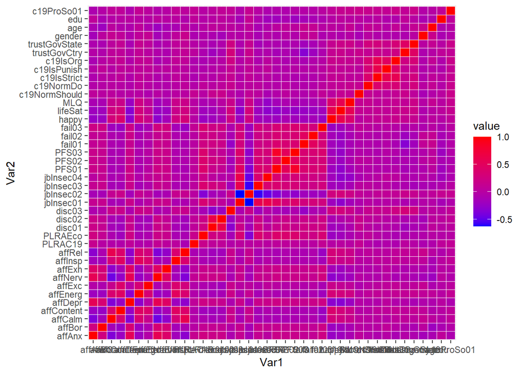

```r
#plotting a correlation heatmap for c19ProSo01
focus.cor1 = as.table(round(cor(focuscountry_pro1[1:40],
                                    use = "pairwise.complete.obs"), digit = 2))
focus.cor1 = melt(focus.cor1) #convert table into long format
heatmap1 = ggplot(data = focus.cor1, aes(x=Var1, y=Var2, fill=value))
heatmap1 = heatmap1 +
  geom_tile(color = "white") +
  scale_fill_gradient(low = "blue", high = "red")

heatmap1
```

**Analysing how well participants responses in Italy predict c19ProSo02**

c19ProSo02 collects the information on how willing people are to make donations to help others who suffer from Coronavirus. According to the summary of the fitted model using linear regression, PFS01 and c19NormShould appears to be the best predictors for this pro social behaviour due to having the lowest p-values among the rest of the potential predictors. jbInsec02, jbInsec03 and fail02 seem like potential predictors too (because a p-value lower than 0.05), but we would barely have enough evidence to prove of them being strong predictors. According to the correlation heatmap, PFS01 has a negative correlation to c19ProSo02, and c19NormShould has a positive correlation to c19ProSo02.

```r
#create datasets with only the predictors and one pro-social attribute each for linear modelling
focuscountry_pro2 = select(focuscountry_data, -c(c19ProSo01, c19ProSo03, c19ProSo04))
#create a linear regression model for all pro-social attr
italy2.fit <-lm(c19ProSo02 ~ ., data = focuscountry_pro2, na.action = na.exclude)
#check for significant predictors for all pro-social attitude attributes
summary(italy2.fit)
```

```
##
## Call:
## lm(formula = c19ProSo02 ~ ., data = focuscountry_pro2, na.action = na.exclude)
##
## Residuals:
##     Min      1Q  Median      3Q     Max
## -4.4948 -0.8074  0.1966  0.9564  3.4421
##
## Coefficients:
##                 Estimate Std. Error t value Pr(>|t|)
## (Intercept)   -1.3264301  0.7748599  -1.712  0.08762 .
## affAnx         0.0726114  0.0740261   0.981  0.32718
## affBor         0.0345788  0.0581426   0.595  0.55233
## affCalm       -0.0485609  0.0827531  -0.587  0.55762
## affContent     0.0806813  0.0907167   0.889  0.37428
## affDepr        0.0218378  0.0812310   0.269  0.78818
## affEnerg      -0.0071374  0.0841942  -0.085  0.93248
## affExc        -0.0431951  0.0822887  -0.525  0.59990
## affNerv       -0.0426261  0.0802606  -0.531  0.59562
## affExh        -0.0006122  0.0680062  -0.009  0.99282
## affInsp        0.1025493  0.0781898   1.312  0.19035
## affRel        -0.1141557  0.0848604  -1.345  0.17924
## PLRAC19        0.0685267  0.0553223   1.239  0.21611
## PLRAEco       -0.0169571  0.0511787  -0.331  0.74055
## disc01         0.0342912  0.1054315   0.325  0.74515
## disc02         0.1526341  0.1042563   1.464  0.14389
## disc03         0.1652738  0.0849564   1.945  0.05236 .
## jbInsec01      0.0459763  0.0863384   0.533  0.59464
## jbInsec02      0.2122967  0.0841068   2.524  0.01194 *
## jbInsec03      0.1374739  0.0693056   1.984  0.04791 *
## jbInsec04     -0.0217482  0.0768199  -0.283  0.77723
## PFS01         -0.3915792  0.1237551  -3.164  0.00166 **
## PFS02          0.0269460  0.0839008   0.321  0.74824
## PFS03          0.2082109  0.1182681   1.761  0.07901 .
## fail01        -0.0350957  0.0784773  -0.447  0.65494
## fail02        -0.1748350  0.0795211  -2.199  0.02842 *
## fail03         0.0811871  0.0786302   1.033  0.30239
## happy          0.0028789  0.0492584   0.058  0.95342
## lifeSat        0.1610605  0.0892756   1.804  0.07189 .
## MLQ           -0.0079498  0.0606837  -0.131  0.89583
## c19NormShould  0.1434585  0.0552924   2.595  0.00978 **
## c19NormDo      0.0928602  0.0544667   1.705  0.08891 .
## c19IsStrict   -0.0450144  0.0864719  -0.521  0.60293
## c19IsPunish   -0.0003741  0.0687189  -0.005  0.99566
## c19IsOrg       0.0372770  0.0725952   0.513  0.60786
## trustGovCtry   0.1526804  0.0796676   1.916  0.05594 .
## trustGovState  0.1637472  0.0914782   1.790  0.07413 .
## gender        -0.1538949  0.1393949  -1.104  0.27018
## age           -0.0402647  0.0473757  -0.850  0.39584
## edu           -0.0381602  0.0571023  -0.668  0.50430
## ---
## Signif. codes:  0 '***' 0.001 '**' 0.01 '*' 0.05 '.' 0.1 ' ' 1
##
## Residual standard error: 1.411 on 446 degrees of freedom
##   (781 observations deleted due to missingness)
## Multiple R-squared:  0.2634, Adjusted R-squared:  0.199
## F-statistic:  4.09 on 39 and 446 DF,  p-value: 1.331e-13
```

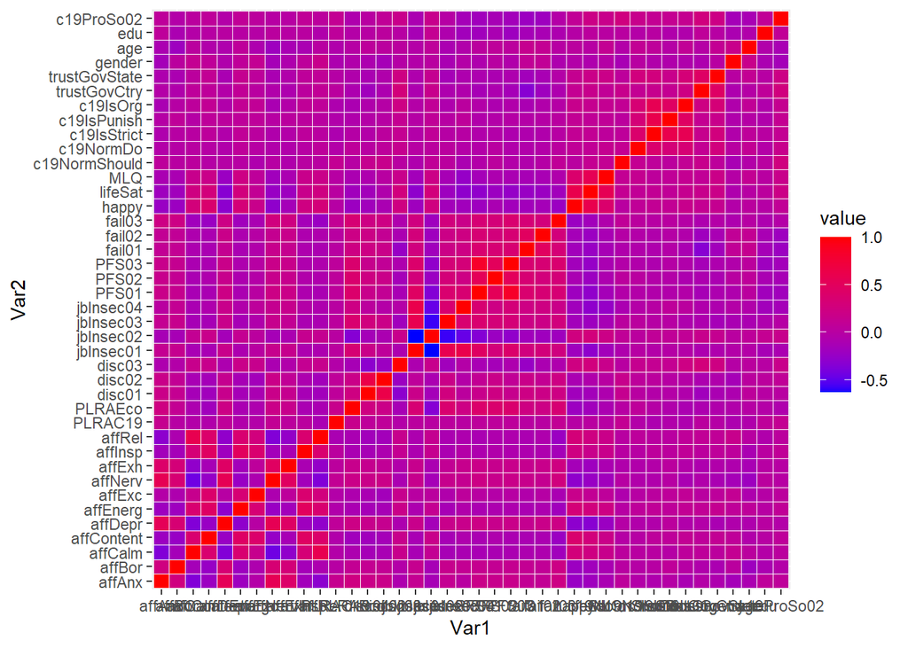

```r
#plotting a correlation heatmap for c19ProSo02
focus.cor2 = as.table(round(cor(focuscountry_pro2[1:40],
                                    use = "pairwise.complete.obs"), digit = 2))
focus.cor2 = melt(focus.cor2)
heatmap2 = ggplot(data = focus.cor2, aes(x=Var1, y=Var2, fill=value))
heatmap2 = heatmap2 +
  geom_tile(color = "white") +
  scale_fill_gradient(low = "blue", high = "red")

heatmap2
```

**Analysing how well participants responses in Italy predict c19ProSo03**

c19ProSo03 collects the information on how willing people are to protect vulnerable groups from coronavirus even at their own expense. According to the summary of the fitted model using linear regression, c19NormDo appears to be the best predictor for this pro social behaviour due to having the lowest p-values among the rest of the potential predictors, and a strong predictor as well. affContent is the second best predictor after c19NormDo, and PLRAC19, fail02, fail03, edu can be considered as potential predictors too, but we would barely have enough evidence to prove of them being strong predictors. According to the correlation heatmap, c19NormDo has a positive correlation to c19ProSo03.

```r
#create datasets with only the predictors and one pro-social attribute each for linear modelling
focuscountry_pro3 = select(focuscountry_data, -c(c19ProSo01, c19ProSo02, c19ProSo04))
#create a linear regression model for all pro-social attr
italy3.fit <-lm(c19ProSo03 ~ ., data = focuscountry_pro3, na.action = na.exclude)
#check for significant predictors for all pro-social attitude attributes
summary(italy3.fit)
```

```
##
## Call:
## lm(formula = c19ProSo03 ~ ., data = focuscountry_pro3, na.action = na.exclude)
##
## Residuals:
##     Min      1Q  Median      3Q     Max
## -4.4386 -0.8032  0.0453  0.9350  3.6144
##
## Coefficients:
##                Estimate Std. Error t value Pr(>|t|)
## (Intercept)   -2.851791   0.772011  -3.694 0.000248 ***
## affAnx         0.101870   0.073754   1.381 0.167905
## affBor         0.001437   0.057929   0.025 0.980216
## affCalm       -0.075234   0.082449  -0.912 0.362002
## affContent     0.263393   0.090383   2.914 0.003746 **
## affDepr        0.017069   0.080932   0.211 0.833058
## affEnerg       0.005891   0.083885   0.070 0.944044
## affExc        -0.093240   0.081986  -1.137 0.256039
## affNerv        0.017124   0.079965   0.214 0.830530
## affExh         0.064732   0.067756   0.955 0.339908
## affInsp        0.081062   0.077902   1.041 0.298644
## affRel        -0.051823   0.084548  -0.613 0.540227
## PLRAC19        0.115545   0.055119   2.096 0.036620 *
## PLRAEco       -0.065776   0.050991  -1.290 0.197735
## disc01         0.180062   0.105044   1.714 0.087194 .
## disc02         0.050997   0.103873   0.491 0.623696
## disc03         0.071202   0.084644   0.841 0.400688
## jbInsec01      0.150065   0.086021   1.745 0.081759 .
## jbInsec02      0.139513   0.083798   1.665 0.096638 .
## jbInsec03      0.103185   0.069051   1.494 0.135795
## jbInsec04     -0.131256   0.076537  -1.715 0.087055 .
## PFS01         -0.124691   0.123300  -1.011 0.312429
## PFS02         -0.137719   0.083592  -1.648 0.100158
## PFS03          0.152483   0.117833   1.294 0.196315
## fail01        -0.112540   0.078189  -1.439 0.150757
## fail02        -0.197143   0.079229  -2.488 0.013200 *
## fail03         0.172778   0.078341   2.205 0.027931 *
## happy          0.065560   0.049077   1.336 0.182280
## lifeSat       -0.011205   0.088947  -0.126 0.899806
## MLQ            0.071500   0.060461   1.183 0.237603
## c19NormShould  0.040551   0.055089   0.736 0.462059
## c19NormDo      0.217229   0.054266   4.003 7.32e-05 ***
## c19IsStrict   -0.069507   0.086154  -0.807 0.420223
## c19IsPunish    0.041702   0.068466   0.609 0.542776
## c19IsOrg       0.127233   0.072328   1.759 0.079246 .
## trustGovCtry   0.087904   0.079375   1.107 0.268692
## trustGovState  0.058137   0.091142   0.638 0.523884
## gender         0.101943   0.138882   0.734 0.463318
## age           -0.043754   0.047201  -0.927 0.354449
## edu            0.131552   0.056892   2.312 0.021216 *
## ---
## Signif. codes:  0 '***' 0.001 '**' 0.01 '*' 0.05 '.' 0.1 ' ' 1
##
## Residual standard error: 1.406 on 446 degrees of freedom
##   (781 observations deleted due to missingness)
## Multiple R-squared:  0.2707, Adjusted R-squared:  0.207
## F-statistic: 4.246 on 39 and 446 DF,  p-value: 2.373e-14
```

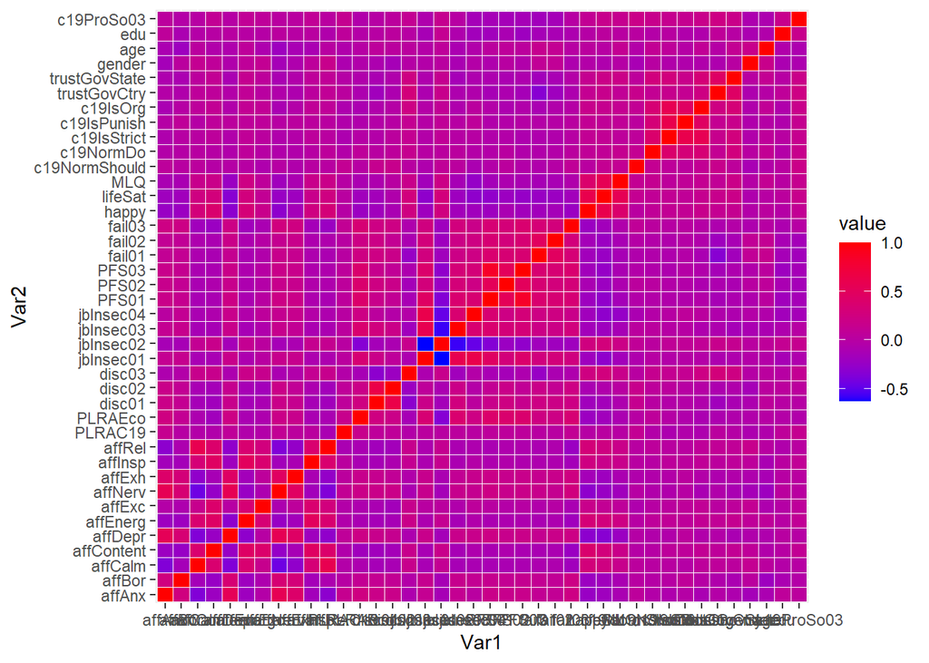

```r
#plotting a correlation heatmap for c19ProSo03
focus.cor3 = as.table(round(cor(focuscountry_pro3[1:40],
                                    use = "pairwise.complete.obs"), digit = 2))
focus.cor3 = melt(focus.cor3)
heatmap3 = ggplot(data = focus.cor3, aes(x=Var1, y=Var2, fill=value))
heatmap3 = heatmap3 +
  geom_tile(color = "white") +
  scale_fill_gradient(low = "blue", high = "red")

heatmap3
```

**Analysing how well participants responses in Italy predict c19ProSo04**

c19ProSo04 collects the information on how willing people are to make personal sacrifices to prevent the spread of coronavirus. According to the summary of the fitted model using linear regression, fail02 and c19NormShould appears to be the most significant predictors for this pro social behaviour due to having the lowest p-values among the rest of the potential predictors. trustGovCtry and disc02 is the second best potential predictor, and affExc, jbInsec02, c19IsStrict, MLQ can be considered as potential predictors too, but we would barely have enough evidence to prove of them being strong predictors. According to the correlation heatmap, fail02 has a negative correlation to c19ProSo04, and positive correlation to c19ProSo04.

```r
#create datasets with only the predictors and one pro-social attribute each for linear modelling
focuscountry_pro4 = select(focuscountry_data, -c(c19ProSo01, c19ProSo02, c19ProSo03))
#create a linear regression model for all pro-social attr
italy4.fit <-lm(c19ProSo04 ~ ., data = focuscountry_pro4, na.action = na.exclude)
#check for significant predictors for all pro-social attitude attributes
summary(italy4.fit)
```

```
##
## Call:
## lm(formula = c19ProSo04 ~ ., data = focuscountry_pro4, na.action = na.exclude)
##
## Residuals:
##     Min      1Q  Median      3Q     Max
## -4.8601 -0.6055  0.1329  0.7425  2.6983
##
## Coefficients:
##                Estimate Std. Error t value Pr(>|t|)
## (Intercept)   -0.866133   0.628039  -1.379 0.168554
## affAnx         0.011542   0.059899   0.193 0.847287
## affBor         0.082816   0.047100   1.758 0.079383 .
## affCalm        0.037935   0.067043   0.566 0.571792
## affContent     0.093884   0.073457   1.278 0.201887
## affDepr       -0.111724   0.065734  -1.700 0.089900 .
## affEnerg       0.024604   0.068130   0.361 0.718169
## affExc        -0.159046   0.066584  -2.389 0.017326 *
## affNerv        0.031945   0.065204   0.490 0.624428
## affExh         0.020255   0.055040   0.368 0.713042
## affInsp        0.030760   0.063267   0.486 0.627072
## affRel        -0.032063   0.068667  -0.467 0.640778
## PLRAC19        0.084893   0.044895   1.891 0.059285 .
## PLRAEco       -0.004851   0.041411  -0.117 0.906802
## disc01        -0.062294   0.085460  -0.729 0.466431
## disc02         0.229500   0.084426   2.718 0.006817 **
## disc03        -0.028191   0.069055  -0.408 0.683297
## jbInsec01     -0.009768   0.069860  -0.140 0.888860
## jbInsec02      0.135716   0.068135   1.992 0.046996 *
## jbInsec03      0.102308   0.056159   1.822 0.069162 .
## jbInsec04      0.003636   0.062178   0.058 0.953398
## PFS01          0.084099   0.100400   0.838 0.402681
## PFS02          0.107688   0.067898   1.586 0.113445
## PFS03         -0.092049   0.095844  -0.960 0.337374
## fail01         0.064022   0.063854   1.003 0.316582
## fail02        -0.238504   0.064372  -3.705 0.000238 ***
## fail03         0.064324   0.063726   1.009 0.313334
## happy         -0.029231   0.040374  -0.724 0.469434
## lifeSat       -0.017128   0.072333  -0.237 0.812926
## MLQ            0.126430   0.049184   2.571 0.010478 *
## c19NormShould  0.266666   0.044881   5.942  5.7e-09 ***
## c19NormDo     -0.013831   0.044093  -0.314 0.753923
## c19IsStrict    0.176114   0.070071   2.513 0.012310 *
## c19IsPunish   -0.090833   0.055851  -1.626 0.104588
## c19IsOrg       0.079034   0.058746   1.345 0.179195
## trustGovCtry   0.203803   0.064555   3.157 0.001702 **
## trustGovState -0.015909   0.074033  -0.215 0.829947
## gender        -0.049645   0.113095  -0.439 0.660896
## age           -0.002246   0.038345  -0.059 0.953316
## edu            0.031660   0.046258   0.684 0.494066
## ---
## Signif. codes:  0 '***' 0.001 '**' 0.01 '*' 0.05 '.' 0.1 ' ' 1
##
## Residual standard error: 1.142 on 445 degrees of freedom
##   (782 observations deleted due to missingness)
## Multiple R-squared:  0.3299, Adjusted R-squared:  0.2711
## F-statistic: 5.616 on 39 and 445 DF,  p-value: < 2.2e-16
```

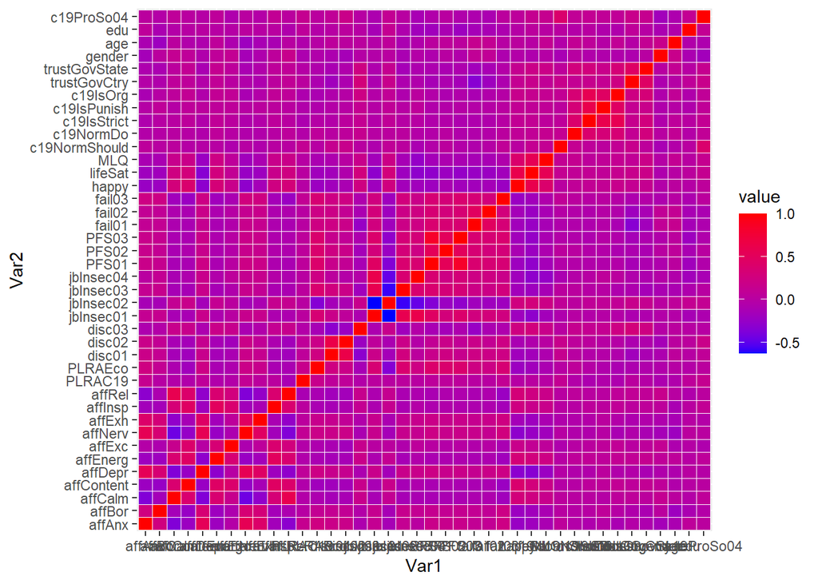

```r
#plotting a correlation heatmap for c19ProSo04
focus.cor4 = as.table(round(cor(focuscountry_pro4[1:40],
                                    use = "pairwise.complete.obs"), digit = 2))
focus.cor4 = melt(focus.cor4)
heatmap4 = ggplot(data = focus.cor4, aes(x=Var1, y=Var2, fill=value))
heatmap4 = heatmap4 +
  geom_tile(color = "white") +
  scale_fill_gradient(low = "blue", high = "red")

heatmap4
```

###### **2(c)**

**Analysing how well participants responses in other countries predict c19ProSo01**

Predictors such as affEnerg, affExh, affInsp, PLRAC19, disc02, PFS02, fail03, lifeSat, MLQ, c19NormShould, c19NormDo, c19IsOrg, trustGovState appear to be significant predictors for the aforementioned pro-social behaviour. affDepr, PLRAEco, jbInsec04, fail01, fail02, c19IsStrict, gender are the next best predictors with a relatively low p-value as well.

```r
#create data sets with only the predictors and one pro-social attribute each for linear modelling
othercountries_pro1 = select(othercountries_data, -c(c19ProSo02, c19ProSo03, c19ProSo04))
#create a linear regression model for all pro-social attr
other1.fit <-lm(c19ProSo01 ~ ., data = othercountries_pro1, na.action = na.exclude)
#check for significant predictors for all pro-social attitude attributes
summary(other1.fit)
```

```
##
## Call:
## lm(formula = c19ProSo01 ~ ., data = othercountries_pro1, na.action = na.exclude)
##
## Residuals:
##     Min      1Q  Median      3Q     Max
## -5.1779 -0.7365  0.1643  0.9487  4.6176
##
## Coefficients:
##                 Estimate Std. Error t value Pr(>|t|)
## (Intercept)   -1.5519632  0.1047018 -14.823  < 2e-16 ***
## affAnx        -0.0142141  0.0115786  -1.228 0.219606
## affBor         0.0125063  0.0088651   1.411 0.158342
## affCalm        0.0175135  0.0126540   1.384 0.166365
## affContent    -0.0311864  0.0121814  -2.560 0.010470 *
## affDepr        0.0324347  0.0115153   2.817 0.004858 **
## affEnerg       0.0430059  0.0120231   3.577 0.000349 ***
## affExc         0.0223282  0.0112915   1.977 0.048007 *
## affNerv       -0.0138895  0.0118944  -1.168 0.242931
## affExh         0.0357652  0.0100754   3.550 0.000387 ***
## affInsp        0.0516379  0.0113194   4.562 5.10e-06 ***
## affRel        -0.0127083  0.0125185  -1.015 0.310044
## PLRAC19        0.0546493  0.0076488   7.145 9.35e-13 ***
## PLRAEco        0.0194201  0.0072367   2.684 0.007291 **
## disc01         0.0001726  0.0136986   0.013 0.989950
## disc02         0.1087404  0.0140346   7.748 9.82e-15 ***
## disc03         0.0215287  0.0119476   1.802 0.071573 .
## jbInsec01     -0.0016731  0.0136403  -0.123 0.902379
## jbInsec02      0.0249153  0.0129694   1.921 0.054737 .
## jbInsec03     -0.0078102  0.0110791  -0.705 0.480852
## jbInsec04     -0.0320128  0.0111533  -2.870 0.004106 **
## PFS01         -0.0210181  0.0144610  -1.453 0.146120
## PFS02          0.0421361  0.0120851   3.487 0.000490 ***
## PFS03          0.0263717  0.0137647   1.916 0.055395 .
## fail01        -0.0304862  0.0111684  -2.730 0.006345 **
## fail02        -0.0319351  0.0113117  -2.823 0.004760 **
## fail03         0.0611363  0.0115269   5.304 1.15e-07 ***
## happy          0.0065692  0.0072593   0.905 0.365511
## lifeSat        0.0714872  0.0126605   5.646 1.66e-08 ***
## MLQ            0.0866445  0.0085172  10.173  < 2e-16 ***
## c19NormShould  0.1038391  0.0086669  11.981  < 2e-16 ***
## c19NormDo      0.0574749  0.0079084   7.268 3.81e-13 ***
## c19IsStrict    0.0287341  0.0105594   2.721 0.006511 **
## c19IsPunish   -0.0059843  0.0083097  -0.720 0.471439
## c19IsOrg       0.0594948  0.0101925   5.837 5.40e-09 ***
## trustGovCtry  -0.0077974  0.0104941  -0.743 0.457478
## trustGovState  0.1471809  0.0117926  12.481  < 2e-16 ***
## gender         0.0580210  0.0207324   2.799 0.005138 **
## age            0.0056546  0.0075271   0.751 0.452524
## edu            0.0289516  0.0074173   3.903 9.53e-05 ***
## ---
## Signif. codes:  0 '***' 0.001 '**' 0.01 '*' 0.05 '.' 0.1 ' ' 1
##
## Residual standard error: 1.361 on 18204 degrees of freedom
##   (20235 observations deleted due to missingness)
## Multiple R-squared:  0.1231, Adjusted R-squared:  0.1212
## F-statistic: 65.51 on 39 and 18204 DF,  p-value: < 2.2e-16
```

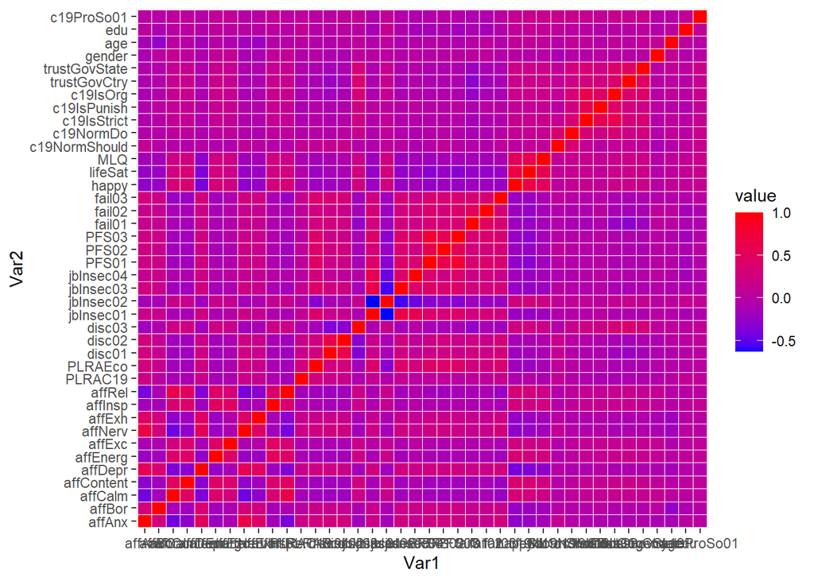

```r
#plotting a correlation heatmap for c19ProSo01
other.cor1 = as.table(round(cor(othercountries_pro1[1:40],
                                    use = "pairwise.complete.obs"), digit = 2))
other.cor1 = melt(other.cor1)
heatmap5 = ggplot(data = other.cor1, aes(x=Var1, y=Var2, fill=value))
heatmap5 = heatmap5 +
  geom_tile(color = "white") +
  scale_fill_gradient(low = "blue", high = "red")

heatmap5
```

**Analysing how well participants responses in other countries predict c19ProSo02**

Predictors such as affAnx, affBor, affExc, affExh, affInsp, PLRAEco, disc02, disc03, jbInsec02, PFS01, fail01, lifeSat, MLQ, c19NormShould, c19NormDo, c19IsOrg, trustGovState, age and edu are all strong predictors. jbInsec01, trustGovCtry are the next best predictors.

```r
#create datasets with only the predictors and one pro-social attribute each for linear modelling
othercountries_pro2 = select(othercountries_data, -c(c19ProSo01, c19ProSo03, c19ProSo04))
#create a linear regression model for all pro-social attr
other2.fit <-lm(c19ProSo02 ~ ., data = othercountries_pro2, na.action = na.exclude)
#check for significant predictors for all pro-social attitude attributes
summary(other2.fit)
```

```
##
## Call:
## lm(formula = c19ProSo02 ~ ., data = othercountries_pro2, na.action = na.exclude)
##
## Residuals:
##     Min      1Q  Median      3Q     Max
## -5.3364 -0.8627  0.2044  1.0868  5.7621
##
## Coefficients:
##                 Estimate Std. Error t value Pr(>|t|)
## (Intercept)   -1.7759648  0.1154917 -15.377  < 2e-16 ***
## affAnx         0.0521440  0.0127721   4.083 4.47e-05 ***
## affBor         0.0655057  0.0097773   6.700 2.15e-11 ***
## affCalm       -0.0205586  0.0139562  -1.473 0.140748
## affContent    -0.0239931  0.0134355  -1.786 0.074149 .
## affDepr        0.0006971  0.0127090   0.055 0.956258
## affEnerg       0.0205044  0.0132606   1.546 0.122057
## affExc         0.0667229  0.0124525   5.358 8.51e-08 ***
## affNerv       -0.0088325  0.0131178  -0.673 0.500753
## affExh         0.0408164  0.0111134   3.673 0.000241 ***
## affInsp        0.0679702  0.0124856   5.444 5.28e-08 ***
## affRel        -0.0228301  0.0138090  -1.653 0.098292 .
## PLRAC19        0.0057310  0.0084367   0.679 0.496958
## PLRAEco       -0.0314325  0.0079815  -3.938 8.24e-05 ***
## disc01         0.0315092  0.0151084   2.086 0.037034 *
## disc02         0.1361424  0.0154781   8.796  < 2e-16 ***
## disc03         0.0558000  0.0131789   4.234 2.31e-05 ***
## jbInsec01      0.0485734  0.0150429   3.229 0.001244 **
## jbInsec02      0.0507570  0.0143070   3.548 0.000390 ***
## jbInsec03      0.0162787  0.0122171   1.332 0.182730
## jbInsec04      0.0051061  0.0123000   0.415 0.678053
## PFS01         -0.1030171  0.0159486  -6.459 1.08e-10 ***
## PFS02          0.0015704  0.0133281   0.118 0.906206
## PFS03          0.0022596  0.0151821   0.149 0.881688
## fail01        -0.0670719  0.0123186  -5.445 5.25e-08 ***
## fail02        -0.0287350  0.0124777  -2.303 0.021295 *
## fail03         0.0291925  0.0127131   2.296 0.021673 *
## happy          0.0142513  0.0080060   1.780 0.075080 .
## lifeSat        0.0610557  0.0139630   4.373 1.23e-05 ***
## MLQ            0.1157278  0.0093940  12.319  < 2e-16 ***
## c19NormShould  0.1430846  0.0095597  14.967  < 2e-16 ***
## c19NormDo      0.0527971  0.0087221   6.053 1.45e-09 ***
## c19IsStrict    0.0277198  0.0116479   2.380 0.017331 *
## c19IsPunish    0.0079291  0.0091666   0.865 0.387051
## c19IsOrg       0.0494575  0.0112402   4.400 1.09e-05 ***
## trustGovCtry   0.0299863  0.0115725   2.591 0.009572 **
## trustGovState  0.1671086  0.0130068  12.848  < 2e-16 ***
## gender        -0.0382809  0.0228730  -1.674 0.094220 .
## age           -0.0345680  0.0082993  -4.165 3.13e-05 ***
## edu            0.0497392  0.0081802   6.080 1.22e-09 ***
## ---
## Signif. codes:  0 '***' 0.001 '**' 0.01 '*' 0.05 '.' 0.1 ' ' 1
##
## Residual standard error: 1.502 on 18205 degrees of freedom
##   (20234 observations deleted due to missingness)
## Multiple R-squared:  0.1559, Adjusted R-squared:  0.1541
## F-statistic: 86.19 on 39 and 18205 DF,  p-value: < 2.2e-16
```

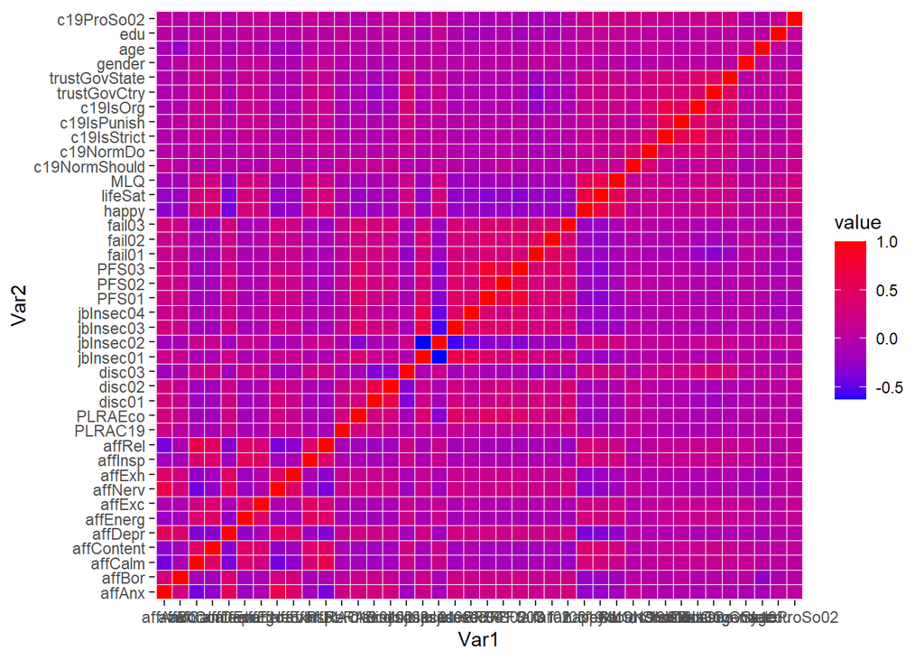

```r
#plotting a correlation heatmap for c19ProSo02
other.cor2 = as.table(round(cor(othercountries_pro2[1:40],
                                    use = "pairwise.complete.obs"), digit = 2))
other.cor2 = melt(other.cor2)
heatmap6 = ggplot(data = other.cor2, aes(x=Var1, y=Var2, fill=value))
heatmap6 = heatmap6 +
  geom_tile(color = "white") +
  scale_fill_gradient(low = "blue", high = "red")

heatmap6
```

**Analysing how well participants responses in other countries predict c19ProSo03**

affDepr, affExh, affInsp, PLRAC19, disc02, disc03, PFS01, fail01, fail03, lifeSat, MLQ, c19NormShould, c19NormDo, c19IsOrg, trustGovCtry, trustGovState, age, edu all appear to be significant predictors of c19ProSo03.

```r
#create datasets with only the predictors and one pro-social attribute each for linear modelling
othercountries_pro3 = select(othercountries_data, -c(c19ProSo01, c19ProSo02, c19ProSo04))
#create a linear regression model for all pro-social attr
other3.fit <-lm(c19ProSo03 ~ ., data = othercountries_pro3, na.action = na.exclude)
#check for significant predictors for all pro-social attitude attributes
summary(other3.fit)
```

```
##
## Call:
## lm(formula = c19ProSo03 ~ ., data = othercountries_pro3, na.action = na.exclude)
##
## Residuals:
##     Min      1Q  Median      3Q     Max
## -5.1321 -0.9725  0.1707  1.1378  5.4080
##
## Coefficients:
##                 Estimate Std. Error t value Pr(>|t|)
## (Intercept)   -1.8568487  0.1190049 -15.603  < 2e-16 ***
## affAnx         0.0242457  0.0131593   1.842 0.065423 .
## affBor        -0.0146688  0.0100782  -1.455 0.145550
## affCalm        0.0179649  0.0143822   1.249 0.211644
## affContent    -0.0050854  0.0138478  -0.367 0.713445
## affDepr        0.0524862  0.0130901   4.010 6.11e-05 ***
## affEnerg       0.0209467  0.0136636   1.533 0.125287
## affExc         0.0331853  0.0128331   2.586 0.009720 **
## affNerv       -0.0268169  0.0135201  -1.983 0.047328 *
## affExh         0.0490917  0.0114525   4.287 1.82e-05 ***
## affInsp        0.0621316  0.0128655   4.829 1.38e-06 ***
## affRel        -0.0356498  0.0142300  -2.505 0.012245 *
## PLRAC19        0.0738983  0.0086944   8.500  < 2e-16 ***
## PLRAEco       -0.0118064  0.0082239  -1.436 0.151126
## disc01        -0.0038643  0.0155741  -0.248 0.804043
## disc02         0.1344051  0.0159516   8.426  < 2e-16 ***
## disc03         0.0744650  0.0135785   5.484 4.21e-08 ***
## jbInsec01      0.0349286  0.0155061   2.253 0.024298 *
## jbInsec02      0.0378122  0.0147410   2.565 0.010322 *
## jbInsec03     -0.0007259  0.0125945  -0.058 0.954037
## jbInsec04      0.0020857  0.0126791   0.165 0.869339
## PFS01         -0.0550902  0.0164375  -3.351 0.000805 ***
## PFS02          0.0089447  0.0137377   0.651 0.514985
## PFS03          0.0002051  0.0156466   0.013 0.989539
## fail01        -0.0600557  0.0126968  -4.730 2.26e-06 ***
## fail02        -0.0191369  0.0128570  -1.488 0.136652
## fail03         0.0502850  0.0131040   3.837 0.000125 ***
## happy         -0.0089772  0.0082524  -1.088 0.276684
## lifeSat        0.0931460  0.0143912   6.472 9.89e-11 ***
## MLQ            0.0621086  0.0096819   6.415 1.44e-10 ***
## c19NormShould  0.1141312  0.0098524  11.584  < 2e-16 ***
## c19NormDo      0.0498490  0.0089903   5.545 2.98e-08 ***
## c19IsStrict    0.0241671  0.0120035   2.013 0.044094 *
## c19IsPunish    0.0028840  0.0094471   0.305 0.760155
## c19IsOrg       0.0798027  0.0115839   6.889 5.80e-12 ***
## trustGovCtry  -0.0478243  0.0119262  -4.010 6.10e-05 ***
## trustGovState  0.1889226  0.0134046  14.094  < 2e-16 ***
## gender         0.0566923  0.0235674   2.406 0.016159 *
## age           -0.0573796  0.0085536  -6.708 2.03e-11 ***
## edu            0.0398557  0.0084326   4.726 2.30e-06 ***
## ---
## Signif. codes:  0 '***' 0.001 '**' 0.01 '*' 0.05 '.' 0.1 ' ' 1
##
## Residual standard error: 1.548 on 18205 degrees of freedom
##   (20234 observations deleted due to missingness)
## Multiple R-squared:  0.1137, Adjusted R-squared:  0.1118
## F-statistic: 59.88 on 39 and 18205 DF,  p-value: < 2.2e-16
```

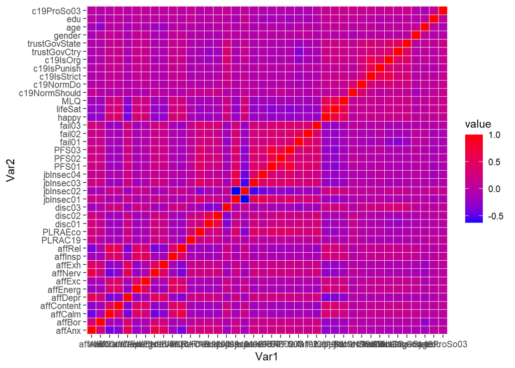

```r
#plotting a correlation heatmap for c19ProSo03
other.cor3 = as.table(round(cor(othercountries_pro3[1:40],
                                    use = "pairwise.complete.obs"), digit = 2))
other.cor3 = melt(other.cor3)
heatmap7 = ggplot(data = other.cor3, aes(x=Var1, y=Var2, fill=value))
heatmap7 = heatmap7 +
  geom_tile(color = "white") +
  scale_fill_gradient(low = "blue", high = "red")

heatmap7
```

**Analysing how well participants responses in other countries predict c19ProSo04**

affExh, PLRAC19, disc02, jbInsec02, PFS02, fail01, fail02, fail03, lifeSat, c19NormShould, c19IsStrict, c19IsPunish, c19IsOrg, trustGovState and age are the most significant predictors for c19ProSo04. jbInsec01, MLQ and trustGovCtry come in next as best predictors.

```r
#create datasets with only the predictors and one pro-social attribute each for linear modelling
othercountries_pro4 = select(othercountries_data, -c(c19ProSo01, c19ProSo02, c19ProSo03))
#create a linear regression model for all pro-social attr
other4.fit <-lm(c19ProSo04 ~ ., data = othercountries_pro4, na.action = na.exclude)
#check for significant predictors for all pro-social attitude attributes
summary(other4.fit)
```

```
##
## Call:
## lm(formula = c19ProSo04 ~ ., data = othercountries_pro4, na.action = na.exclude)
##
## Residuals:
##     Min      1Q  Median      3Q     Max
## -5.4523 -0.7380  0.2714  1.0274  4.8165
##
## Coefficients:
##                Estimate Std. Error t value Pr(>|t|)
## (Intercept)   -1.160962   0.111807 -10.384  < 2e-16 ***
## affAnx         0.036463   0.012363   2.949 0.003187 **
## affBor        -0.015652   0.009467  -1.653 0.098263 .
## affCalm        0.024796   0.013516   1.835 0.066590 .
## affContent     0.017318   0.013011   1.331 0.183173
## affDepr        0.004152   0.012297   0.338 0.735634
## affEnerg       0.005780   0.012836   0.450 0.652468
## affExc        -0.033642   0.012056  -2.791 0.005268 **
## affNerv       -0.024829   0.012703  -1.955 0.050649 .
## affExh         0.042852   0.010759   3.983 6.83e-05 ***
## affInsp        0.023100   0.012087   1.911 0.055986 .
## affRel        -0.011289   0.013372  -0.844 0.398546
## PLRAC19        0.083606   0.008167  10.237  < 2e-16 ***
## PLRAEco        0.003993   0.007728   0.517 0.605389
## disc01        -0.010620   0.014633  -0.726 0.467999
## disc02         0.161758   0.014992  10.790  < 2e-16 ***
## disc03         0.029104   0.012757   2.281 0.022535 *
## jbInsec01      0.043757   0.014569   3.003 0.002673 **
## jbInsec02      0.051152   0.013850   3.693 0.000222 ***
## jbInsec03     -0.008059   0.011836  -0.681 0.495934
## jbInsec04     -0.010772   0.011914  -0.904 0.365956
## PFS01         -0.027450   0.015443  -1.777 0.075503 .
## PFS02          0.084535   0.012910   6.548 5.98e-11 ***
## PFS03         -0.020727   0.014700  -1.410 0.158544
## fail01        -0.091950   0.011929  -7.708 1.34e-14 ***
## fail02        -0.045565   0.012080  -3.772 0.000163 ***
## fail03         0.058125   0.012312   4.721 2.36e-06 ***
## happy         -0.002140   0.007755  -0.276 0.782560
## lifeSat        0.085017   0.013528   6.285 3.36e-10 ***
## MLQ            0.028342   0.009098   3.115 0.001841 **
## c19NormShould  0.263972   0.009256  28.520  < 2e-16 ***
## c19NormDo      0.014477   0.008445   1.714 0.086499 .
## c19IsStrict    0.064702   0.011277   5.737 9.76e-09 ***
## c19IsPunish   -0.046028   0.008875  -5.186 2.17e-07 ***
## c19IsOrg       0.049964   0.010882   4.591 4.43e-06 ***
## trustGovCtry  -0.033255   0.011206  -2.968 0.003006 **
## trustGovState  0.120695   0.012597   9.581  < 2e-16 ***
## gender        -0.006427   0.022141  -0.290 0.771601
## age            0.031321   0.008036   3.897 9.75e-05 ***
## edu            0.013341   0.007922   1.684 0.092206 .
## ---
## Signif. codes:  0 '***' 0.001 '**' 0.01 '*' 0.05 '.' 0.1 ' ' 1
##
## Residual standard error: 1.454 on 18203 degrees of freedom
##   (20236 observations deleted due to missingness)
## Multiple R-squared:  0.1498, Adjusted R-squared:  0.148
## F-statistic: 82.25 on 39 and 18203 DF,  p-value: < 2.2e-16
```

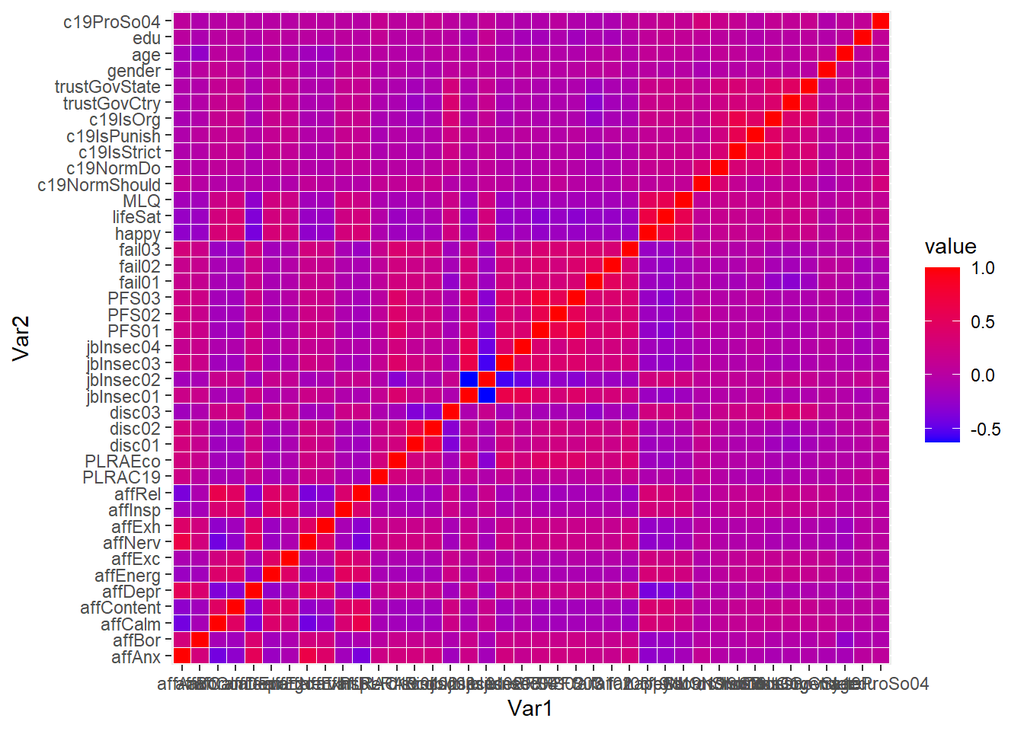

```r
#plotting a correlation heatmap for c19ProSo02
other.cor4 = as.table(round(cor(othercountries_pro4[1:40],
                                    use = "pairwise.complete.obs"), digit = 2))
other.cor4 = melt(other.cor4)
heatmap8 = ggplot(data = other.cor4, aes(x=Var1, y=Var2, fill=value))
heatmap8 = heatmap8 +
  geom_tile(color = "white") +
  scale_fill_gradient(low = "blue", high = "red")

heatmap8
```

**Comparing attributes that are deemed as strong predictors of pro social behaviours between other countries and focus country**

**T-test for c19NormShould**

c19NormShould is a strong predictor for both Italy and other countries in response to pro social behaviours. Test whether people in other countries believe that people should self isolate and engage in social distancing more than the people of Italy.

```r
# Apply 2 sample hypothesis test
t.test(othercountries_data$c19NormShould, focuscountry_data$c19NormShould, "greater",
conf.level = 0.95)
```

```
##
##  Welch Two Sample t-test
##
## data:  othercountries_data$c19NormShould and focuscountry_data$c19NormShould
## t = 1.226, df = 1349.8, p-value = 0.1102
## alternative hypothesis: true difference in means is greater than 0
## 95 percent confidence interval:
##  -0.01559309         Inf
## sample estimates:
## mean of x mean of y
##  2.006841  1.961326
```

From the result above, the null hypothesis is accepted, which means people of Italy and other countries both have the same opinion on which degree people should self isolate and engage in social distancing because the p-value is larger than 0.05.

**T-test for jbInsec02**

jbInsec02 appeared to be significant predictors for c19ProSo01 in Italy and c19ProSo04 in other countries. Test whether the people in Italy are more certain that they can keep their job as compared to people in other countries.

```r
# Apply 2 sample hypothesis test
t.test(othercountries_data$jbInsec02, focuscountry_data$jbInsec02, "less",
conf.level = 0.95)
```

```
##
##  Welch Two Sample t-test
##
## data:  othercountries_data$jbInsec02 and focuscountry_data$jbInsec02
## t = 4.7156, df = 850.86, p-value = 1
## alternative hypothesis: true difference in means is less than 0
## 95 percent confidence interval:
##       -Inf 0.2596166
## sample estimates:
## mean of x mean of y
##  0.567424  0.375000
```

**T-test for c19NormDo**

c19NormDo is another significant predictor for many pro-social behaviors. Test whether people in Italy believe that their community does self isolation and engage in social distancing more than what people in other countries think.

```r
# Apply 2 sample hypothesis test
t.test(othercountries_data$c19NormDo, focuscountry_data$c19NormDo, "less",
conf.level = 0.95)
```

```
##
##  Welch Two Sample t-test
##
## data:  othercountries_data$c19NormDo and focuscountry_data$c19NormDo
## t = 1.5223, df = 1361.1, p-value = 0.9359
## alternative hypothesis: true difference in means is less than 0
## 95 percent confidence interval:
##      -Inf 0.129504
## sample estimates:
## mean of x mean of y
##  1.299982  1.237757
```

It is concluded that the null hypothesis is accepted, which means the people from both locations have the same opinion on whether societies in their respective countries do self isolation and engage in social distancing. This is due to the p-value being larger than 0.05.

**T-test for PFS01**

Test whether the people in other countries feel more financially strained compared to Italians.

```r
# Apply 2 sample hypothesis test
t.test(othercountries_data$PFS01, focuscountry_data$PFS01, "greater",
conf.level = 0.95)
```

```
##
##  Welch Two Sample t-test
##
## data:  othercountries_data$PFS01 and focuscountry_data$PFS01
## t = 6.589, df = 1359.6, p-value = 3.157e-11
## alternative hypothesis: true difference in means is greater than 0
## 95 percent confidence interval:
##  0.1605525       Inf
## sample estimates:
##   mean of x   mean of y
## -0.02095372 -0.23496835
```

Based on the results above, we can safely reject the null hypothesis as the p-value is lesser than 0.05. This means that there is enough evidence to prove that people in other countries indeed experience more financial strain as compared to Italy.

**T-test for fail02**

fail02 asks to agree or disagree that, if one compares themselves to others in their own country, their group is worse off. Test whether Italians agree to the statement of fail02 more than people in other countries.

```r
# Apply 2 sample hypothesis test
t.test(focuscountry_data$fail02, othercountries_data$fail02, "greater",
conf.level = 0.95)
```

```
##
##  Welch Two Sample t-test
##
## data:  focuscountry_data$fail02 and othercountries_data$fail02
## t = 4.7935, df = 1361.2, p-value = 9.093e-07
## alternative hypothesis: true difference in means is greater than 0
## 95 percent confidence interval:
##  0.0946675       Inf
## sample estimates:
##  mean of x  mean of y
## -0.2717220 -0.4158947
```

We are able to deduce that the null hypothesis is rejected, where the p-value is lesser than 0.05, therefore there is enough evidence to prove that Italians, on the scale from strongly disagree to strongly agree, are leaning more towards the right of the scale compared to people in other countries.